# HW 3

Nisanth Dheram

11-8-2016

## Introduction

You have recently joined the data science team at Target, and your manager has come to you to help her solve an important (and high visibility) question to the firm. The Target.com and Advertising & Marketing groups have a joint initiative to better target customers with sponsored search advertising (also known as âpaid searchâ or just âsearch advertisingâ) for products online. The teams cite search advertising as an important and effective marketing channel for Target.com (and the entire Target firm more broadly). The effectiveness of search advertising is attributed to the fact that search engines match the ads shown to a consumer with their current search intent derived from the keyword being used. It subsequently presents an appropriate list of ads based on factors such as bids placed by the advertisers (e.g., Target) and their historical performance. The ability to present consumers ads tailored to their search context (as indicated by the keywords) considerably increases the likelihood that they will click on one these ads. These teams at Target want to better understand how various features effect the performance of keyword, and are looking to you for guidance. Moreover, they are concerned that they have been following suboptimal bidding strategies by bidding too much on keyword terms that do not correspond to customers who are actually interested (or can be enticed toward) Target products. They fear that because the context of the consumer’s search is not directly observable and its prediction can be nontrivial, they bidding strategy used by Target.com and the Advertising & Marketing groups could be placing too much value on keywords that are too ambiguous. This ambiguity results from the fact that the same keyword might refer to different contexts, and competing advertisers might have different intents while bidding on a particular keyword. Therefore, you are being asked to conduct an analysis to help provide insight into challenge for the teams.

## Goal

The goal of this analysis is to explore how various features effect consumer search behavior. Above this, you will understand the interplay between a keywordâs context and consumersâ search behavior. More specifically, you will need to ascertain how the breadth of a keywordâs context might affect consumer behavior and keyword performance. In reality, keyword contextual ambiguity can result in both higher diversity in ad quality and higher probability of ad irrelevancy. Therefore, how keyword contextual ambiguity would affect consumer click behavior is unclear. To explore this question, you are going to use a rich dataset from a major search engine to perform a cross-category analysis and examine which of these two opposing effects dominates in the context of search advertising.

## Understanding the data

The keyword level variables are in `keywords.csv`, with the following data dictionary

| Field | Description |
| --- | --- |
| num_ads | measures the total number of ads produced for a particular keyword |
| num_clicks | measures the total number of clicks a particular keyword receives |
| num_impressions | denotes the total number of times consumers search for a particular keyword in the dataset |
| num_word | denotes the number of words in the keyword |
| brand | does the keyword refer to a specific brand |
| location | does the keyword refer to a specific location |
| log_trans | a measure of transactional intent, measured by the natural log of the frequency of transactional words that appear in the organic results for this keyword |
| avg_ad_quality | the average quality of ads shown for this keyword, where the quality of an ad is the average click through rate that the ad receives for other keywords |
| avg_num_ads | measures the average number of competing advertisers during an impression, which denotes the competitive intensity for a keyword |
| categoryid | id indicating the keyword’s product category |

Additionally, the folder `organic_text` contains a file for each keyword. Each file contains the title and textual content of the brief description of the top-50-ranked Google organic search results for the given keyword. This text is meant to be a reasonable approximation of text representing the contextual meaning(s) of each keyword.

Open the `keywords.csv` data in R

```r
folder="C:/Users/nisan/Desktop/My Coursework/Fall Semester/Exploratory Data Analytics/Homework 3"
setwd(folder)
keywords<-read.csv("keywords.csv",header=TRUE,stringsAsFactors = FALSE)
```

## Exploration

Using the skills you have amassed over the course, visualize and explore the relationship between the variables in your data and/or the keywords. Highlight and describe any interesting relationships or patterns you discover in the context of this problem. Feel free to transform or compute new variables. One variable you are required to create is click through rate (ctr) which is the proportion of ad impressions that result in actual clicks.

```r
keywords$ctr<-keywords$num_clicks/keywords$num_impressions
#keywords$adsperimp<-keywords$num_ads/keywords$num_impressions

keywords[,c("brand", "location","categoryid")] <- lapply(keywords[,c("brand", "location","categoryid")], factor)

str(keywords)
```

```
## 'data.frame':    1000 obs. of  14 variables:
##  $ querycode      : int  1 2 3 4 5 6 7 8 9 10 ...
##  $ query          : chr  "yellow pages" "sears" "lowes" "white pages" ...
##  $ num_ads        : int  124614 83599 108271 114079 78519 141624 95539 37062 67370 39373 ...
##  $ num_clicks     : int  6984 6149 6095 5362 4589 4284 4221 3834 3627 3263 ...
##  $ num_impressions: int  15943 12498 14019 14676 9916 24851 25120 6846 8669 7637 ...
##  $ num_word       : int  2 1 1 2 2 1 2 1 1 1 ...
##  $ brand          : Factor w/ 2 levels "0","1": 2 2 1 1 2 2 2 2 2 1 ...
##  $ location       : Factor w/ 2 levels "0","1": 1 1 1 2 1 1 1 2 1 1 ...
##  $ log_trans      : num  2.3 3.85 3.64 2.56 3.33 ...
##  $ avg_ad_quality : num  0.0573 0.0757 0.0602 0.0496 0.0653 ...
##  $ log_imp        : num  9.68 9.43 9.55 9.59 9.2 ...
##  $ avg_num_ads    : num  7.8 6.66 7.71 7.75 7.89 ...
##  $ categoryid     : Factor w/ 20 levels "0","1","2","3",..: 11 9 14 11 12 9 19 9 5 9 ...
##  $ ctr            : num  0.438 0.492 0.435 0.365 0.463 ...
```

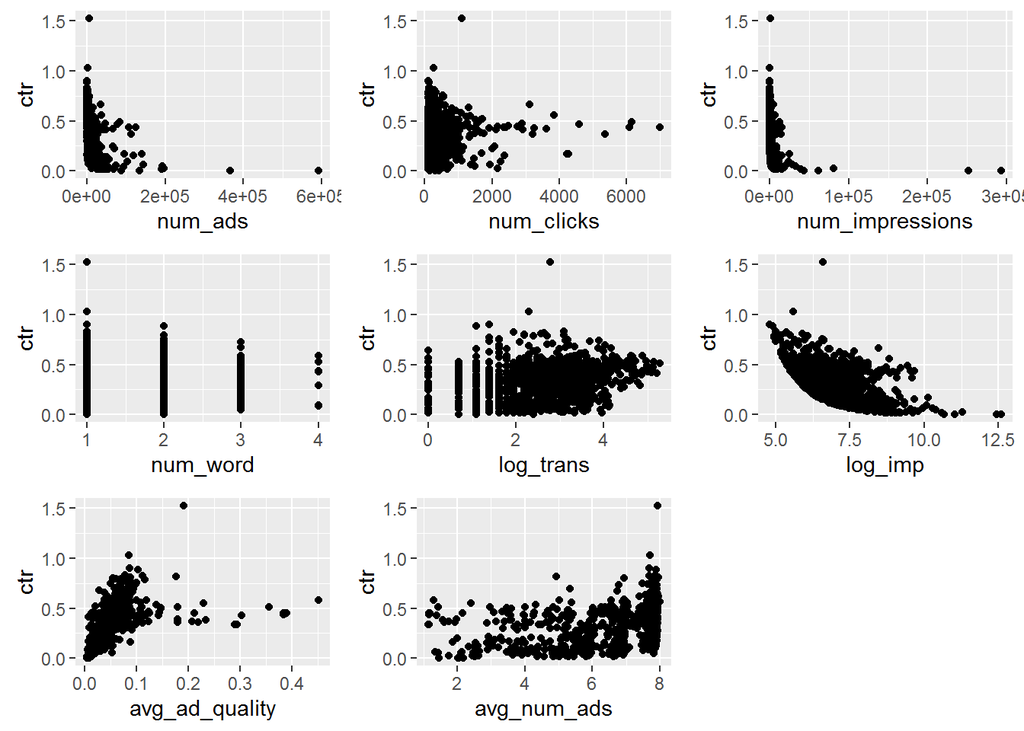

```r
#Observing the variation of CTR across numeric features
p1<-ggplot(keywords, aes(num_ads, ctr)) +geom_point()
p2<-ggplot(keywords, aes(num_clicks, ctr)) +geom_point()
p3<-ggplot(keywords, aes(num_impressions, ctr)) +geom_point()
p4<-ggplot(keywords, aes(num_word, ctr)) +geom_point()
#grid.arrange( p1, p2,p3,p4,nrow=2 ,ncol=2)

p5<-ggplot(keywords, aes(log_trans, ctr)) +geom_point()
p6<-ggplot(keywords, aes(log_imp, ctr)) +geom_point()
p7<-ggplot(keywords, aes(avg_ad_quality, ctr)) +geom_point()
p8<-ggplot(keywords, aes(avg_num_ads, ctr)) +geom_point()
grid.arrange(p1, p2,p3,p4, p5, p6,p7,p8,nrow=3 ,ncol=3)
```

**We observe that features such as num_ads, num_clicks and avg_num_ads have a nearly logarithmic relationship with CTR. We can modify these variables when we regress them with CTR.**

**CTR seems to reduce with increase in num_ads but increases with increase in number of avg_num_ads.**

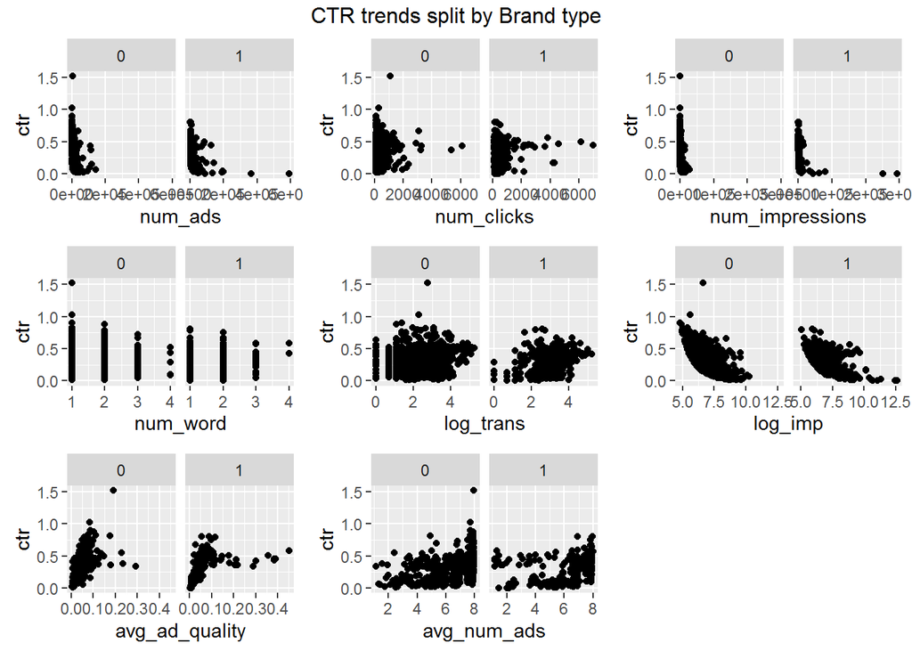

```r
#Observing the trend of CTR with features across brand type
p11<-ggplot(keywords, aes(num_ads, ctr)) +geom_point()+facet_grid(~brand)
p12<-ggplot(keywords, aes(num_clicks, ctr)) +geom_point()+facet_grid(~brand)
p13<-ggplot(keywords, aes(num_impressions, ctr)) +geom_point()+facet_grid(~brand)
p14<-ggplot(keywords, aes(num_word, ctr)) +geom_point()+facet_grid(~brand)
#grid.arrange( p1, p2,p3,p4,nrow=2 ,ncol=2)

p15<-ggplot(keywords, aes(log_trans, ctr)) +geom_point()+facet_grid(~brand)
p16<-ggplot(keywords, aes(log_imp, ctr)) +geom_point()+facet_grid(~brand)
p17<-ggplot(keywords, aes(avg_ad_quality, ctr)) +geom_point()+facet_grid(~brand)
p18<-ggplot(keywords, aes(avg_num_ads, ctr)) +geom_point()+facet_grid(~brand)
grid.arrange(p11, p12,p13,p14, p15, p16,p17,p18,nrow=3 ,ncol=3,top ="CTR trends split by Brand type")
```

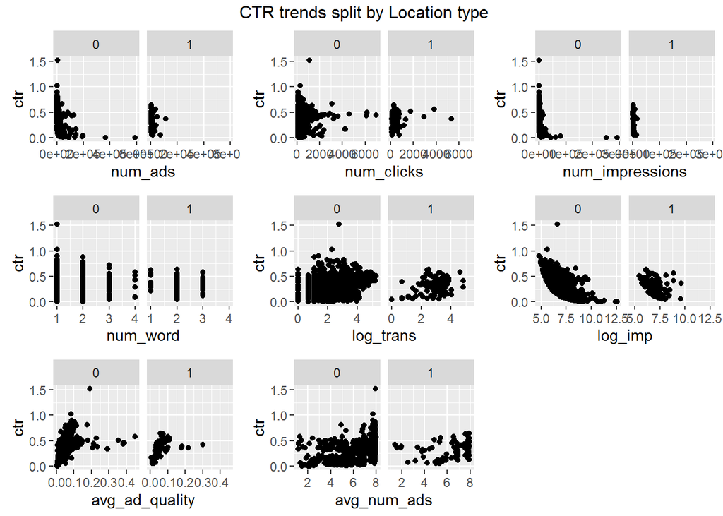

```r
#Observing the trend of CTR with features across location type
p11<-ggplot(keywords, aes(num_ads, ctr)) +geom_point()+facet_grid(~location)
p12<-ggplot(keywords, aes(num_clicks, ctr)) +geom_point()+facet_grid(~location)
p13<-ggplot(keywords, aes(num_impressions, ctr)) +geom_point()+facet_grid(~location)
p14<-ggplot(keywords, aes(num_word, ctr)) +geom_point()+facet_grid(~location)
#grid.arrange( p1, p2,p3,p4,nrow=2 ,ncol=2)

p15<-ggplot(keywords, aes(log_trans, ctr)) +geom_point()+facet_grid(~location)
p16<-ggplot(keywords, aes(log_imp, ctr)) +geom_point()+facet_grid(~location)
p17<-ggplot(keywords, aes(avg_ad_quality, ctr)) +geom_point()+facet_grid(~location)
p18<-ggplot(keywords, aes(avg_num_ads, ctr)) +geom_point()+facet_grid(~location)
grid.arrange(p11, p12,p13,p14, p15, p16,p17,p18,nrow=3 ,ncol=3,top =" CTR trends split by Location type")
```

**The relationship of the features with CTR does not seem to vary much based on brand or location type of keywords.**

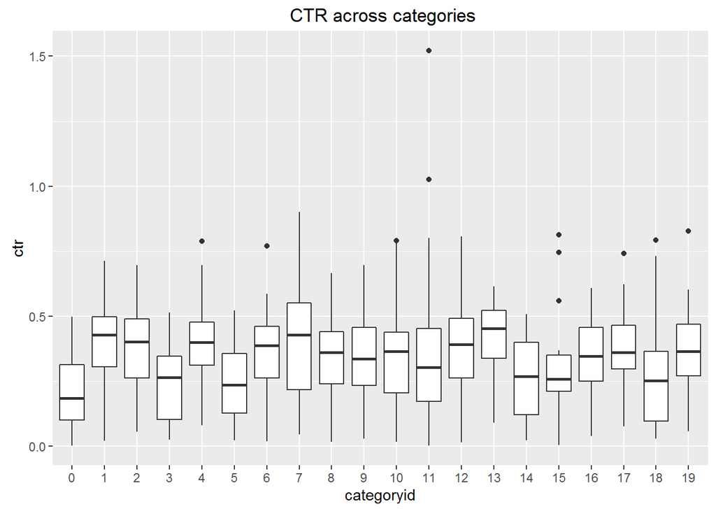

```r
#Observing the distribution of CTR across categories
ggplot(keywords, aes(categoryid,ctr))+geom_boxplot()+labs(title =" CTR across categories")
```

```r
summary(keywords %>% filter(categoryid == 13))
```

```
##    querycode        query              num_ads         num_clicks
##  Min.   :  3.0   Length:36          Min.   :  1382   Min.   : 106.0
##  1st Qu.:334.0   Class :character   1st Qu.:  2286   1st Qu.: 129.2
##  Median :523.0   Mode  :character   Median :  2872   Median : 208.0
##  Mean   :536.4                      Mean   :  9164   Mean   : 522.7
##  3rd Qu.:812.0                      3rd Qu.:  7898   3rd Qu.: 315.5
##  Max.   :998.0                      Max.   :108271   Max.   :6095.0
##
##  num_impressions      num_word     brand  location   log_trans
##  Min.   :  176.0   Min.   :1.000   0:22   0:32     Min.   :1.609
##  1st Qu.:  299.5   1st Qu.:1.000   1:14   1: 4     1st Qu.:2.996
##  Median :  529.5   Median :2.000                   Median :3.541
##  Mean   : 1438.6   Mean   :1.694                   Mean   :3.347
##  3rd Qu.: 1319.2   3rd Qu.:2.000                   3rd Qu.:3.670
##  Max.   :14019.0   Max.   :3.000                   Max.   :4.290
##
##  avg_ad_quality        log_imp       avg_num_ads      categoryid
##  Min.   :0.009249   Min.   :5.170   Min.   :1.166   13     :36
##  1st Qu.:0.044804   1st Qu.:5.702   1st Qu.:6.871   0      : 0
##  Median :0.061793   Median :6.269   Median :7.660   1      : 0
##  Mean   :0.076219   Mean   :6.542   Mean   :6.874   2      : 0
##  3rd Qu.:0.073750   3rd Qu.:7.174   3rd Qu.:7.834   3      : 0
##  Max.   :0.389887   Max.   :9.548   Max.   :7.938   4      : 0
##                                                     (Other): 0
##       ctr
##  Min.   :0.08931
##  1st Qu.:0.33792
##  Median :0.45179
##  Mean   :0.41254
##  3rd Qu.:0.52167
##  Max.   :0.61364
##
```

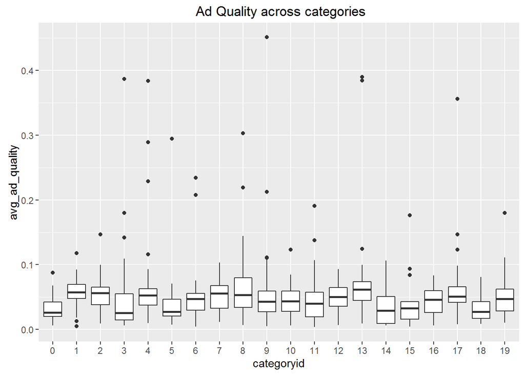

```r
ggplot(keywords, aes(categoryid,avg_ad_quality)) +geom_boxplot()+ labs(title =" Ad Quality across categories")
```

**Category13 has the highest average CTR which seems to be majorly due to the high avg_ad_quality as compared to other categories**

## Modeling

The Target teams are concerned with understanding how click-through-rate (ctr) is affected by other features in the `keyword.csv` dataset. Regress ctr on `num_ads`, `num_word`, `brand`, `location`,`log_trans`, `avg_ad_quality` and/or any other interactions or variables you created from your exploration.

```r
#Using the above observed trends to modify features and run linear regression with CTR

reg<-with(keywords,lm(ctr ~ log(num_ads)
                      +log_imp
                      +num_word
                      +brand
                      +location
                      +log_trans
                      +avg_ad_quality
                      +log(avg_num_ads)
                      +categoryid
                      ))
summary(reg)
```

```
##
## Call:
## lm(formula = ctr ~ log(num_ads) + log_imp + num_word + brand +
##     location + log_trans + avg_ad_quality + log(avg_num_ads) +
##     categoryid)
##
## Residuals:
##      Min       1Q   Median       3Q      Max
## -0.42609 -0.05923 -0.00560  0.05341  0.39514
##
## Coefficients:
##                    Estimate Std. Error t value Pr(>|t|)
## (Intercept)       -0.002483   0.045157  -0.055   0.9562
## log(num_ads)      16.612709   1.006199  16.510   <2e-16 ***
## log_imp          -16.651030   1.005856 -16.554   <2e-16 ***
## num_word          -0.007705   0.004555  -1.691   0.0911 .
## brand1            -0.008148   0.006480  -1.257   0.2089
## location1         -0.001131   0.010059  -0.112   0.9105
## log_trans          0.007545   0.003346   2.255   0.0243 *
## avg_ad_quality     2.126422   0.100973  21.059   <2e-16 ***
## log(avg_num_ads) -16.384559   1.007698 -16.259   <2e-16 ***
## categoryid1        0.030552   0.024850   1.229   0.2192
## categoryid2        0.010268   0.018778   0.547   0.5846
## categoryid3       -0.033118   0.022126  -1.497   0.1348
## categoryid4        0.017696   0.018256   0.969   0.3326
## categoryid5       -0.026561   0.019658  -1.351   0.1770
## categoryid6        0.033196   0.019375   1.713   0.0870 .
## categoryid7        0.027921   0.024370   1.146   0.2522
## categoryid8        0.016783   0.018450   0.910   0.3632
## categoryid9       -0.010663   0.018141  -0.588   0.5568
## categoryid10       0.027504   0.018013   1.527   0.1271
## categoryid11       0.015453   0.016808   0.919   0.3581
## categoryid12       0.007985   0.022157   0.360   0.7186
## categoryid13      -0.001004   0.021648  -0.046   0.9630
## categoryid14      -0.018065   0.026000  -0.695   0.4873
## categoryid15       0.047536   0.026307   1.807   0.0711 .
## categoryid16      -0.014130   0.020743  -0.681   0.4959
## categoryid17       0.007963   0.021708   0.367   0.7138
## categoryid18       0.017592   0.020958   0.839   0.4015
## categoryid19       0.023371   0.021352   1.095   0.2740
## ---
## Signif. codes:  0 '***' 0.001 '**' 0.01 '*' 0.05 '.' 0.1 ' ' 1
##
## Residual standard error: 0.08956 on 972 degrees of freedom
## Multiple R-squared:  0.7539, Adjusted R-squared:  0.7471
## F-statistic: 110.3 on 27 and 972 DF,  p-value: < 2.2e-16
```

```r
#Removing insignificant features and retaining only the significant features

reg<-with(keywords,lm(ctr ~ log(num_ads)
                      +log_imp
                      #+num_word
                      #+brand
                      #+location
                      +log_trans
                      +avg_ad_quality
                      +log(avg_num_ads)
                      +categoryid
                      ))
summary(reg)
```

```
##
## Call:
## lm(formula = ctr ~ log(num_ads) + log_imp + log_trans + avg_ad_quality +
##     log(avg_num_ads) + categoryid)
##
## Residuals:
##      Min       1Q   Median       3Q      Max
## -0.42602 -0.05926 -0.00580  0.05258  0.40243
##
## Coefficients:
##                    Estimate Std. Error t value Pr(>|t|)
## (Intercept)       -0.017165   0.043641  -0.393   0.6942
## log(num_ads)      16.637502   1.002496  16.596   <2e-16 ***
## log_imp          -16.675713   1.002112 -16.641   <2e-16 ***
## log_trans          0.006607   0.003309   1.997   0.0461 *
## avg_ad_quality     2.131813   0.100352  21.243   <2e-16 ***
## log(avg_num_ads) -16.408661   1.004017 -16.343   <2e-16 ***
## categoryid1        0.032320   0.024758   1.305   0.1920
## categoryid2        0.007544   0.018648   0.405   0.6859
## categoryid3       -0.035260   0.022048  -1.599   0.1101
## categoryid4        0.016673   0.018195   0.916   0.3597
## categoryid5       -0.026858   0.019597  -1.371   0.1708
## categoryid6        0.032265   0.019316   1.670   0.0952 .
## categoryid7        0.030492   0.024331   1.253   0.2104
## categoryid8        0.015636   0.018421   0.849   0.3962
## categoryid9       -0.011740   0.018121  -0.648   0.5172
## categoryid10       0.026638   0.018004   1.480   0.1393
## categoryid11       0.014552   0.016682   0.872   0.3832
## categoryid12       0.010299   0.022013   0.468   0.6400
## categoryid13      -0.002055   0.021617  -0.095   0.9243
## categoryid14      -0.018514   0.025894  -0.715   0.4748
## categoryid15       0.045231   0.026222   1.725   0.0849 .
## categoryid16      -0.013060   0.020676  -0.632   0.5277
## categoryid17       0.007608   0.021568   0.353   0.7243
## categoryid18       0.016900   0.020906   0.808   0.4191
## categoryid19       0.024750   0.021350   1.159   0.2466
## ---
## Signif. codes:  0 '***' 0.001 '**' 0.01 '*' 0.05 '.' 0.1 ' ' 1
##
## Residual standard error: 0.08964 on 975 degrees of freedom
## Multiple R-squared:  0.7527, Adjusted R-squared:  0.7466
## F-statistic: 123.6 on 24 and 975 DF,  p-value: < 2.2e-16
```

**Many of these variables have a significant impact on CTR. Following is their individual impact for similar values of other variables:**

**avg_ad_quality: Not surprisingly, CTR increases by 2.13 for a unit increase in avg_ad_quality.**

Turn categoryid into factors, if you have not already, and include this variable into your regression

**Adding categoryid as a predictor gives us a relative comparison of CTR between categories of keywords for similar values of other variables. For example categoryid1 has CTR of 0.03 more than category0**

## Topic Modeling

One of the major questions of the Target teams is how a keywordâs context (and ambiguity thereof) might affect consumer behavior and keyword performance. You will use the recently learned algorithm Latent Dirchlet Allocation to discover topics and measure ambiguity.

First you must pre-process the text before we run use LDA.

```r
dirname <- file.path(getwd(),"organic_text")
docs <- Corpus(DirSource(dirname, encoding = "UTF-8"))

# The following steps pre-process the raw text documents.
# Remove punctuations and numbers because they are generally uninformative.
docs <- tm_map(docs, removePunctuation)
docs <- tm_map(docs, removeNumbers)

# Convert all words to lowercase.
docs <- tm_map(docs, content_transformer(tolower))

# Remove stopwords such as "a", "the", etc.
docs <- tm_map(docs, removeWords, stopwords("english"))

# Use the SnowballC package to do stemming.
docs <- tm_map(docs, stemDocument)

# Remove excess white spaces between words.
docs <- tm_map(docs, stripWhitespace)

# You can inspect the first document to see what it looks like with
#docs[[1]]$content

# Convert all documents to a term frequency matrix.
tfm <- DocumentTermMatrix(docs)

# We can check the dimension of this matrix by calling dim()
#print(dim(tfm))
```

Now that we have finished pre-processing the text, we now can execute LDA to discover topics

```r
# we run LDA with 20 topics, and use Gibbs sampling as our method for identifying the optimal parameters
# Note: this make take some time to run (~10 mins)
#results <- LDA(tfm, k = 20, method = "Gibbs", control = list(seed=1))
results <- LDA(tfm, k = 20, method = "Gibbs")

# Obtain the top w words (i.e., the w most probable words) for each topic, with the optional requirement that their probability is greater than thresh

#feel free to explore with different values of w and thresh
w=7
thresh = 0.010
#Terms <- terms(results, w)
Terms <- terms(results, w,thresh)
Terms
```

```
## $`Topic 1`
## [1] "bank"   "card"   "credit" "insur"  "loan"   "onlin"  "rate"
##
## $`Topic 2`
## [1] "free"  "game"  "onlin" "play"
##
## $`Topic 3`
## [1] "disney" "hotel"  "las"    "resort" "vega"   "world"
##
## $`Topic 4`
## [1] "att"      "chat"     "internet" "mobil"    "phone"    "servic"
## [7] "wireless"
##
## $`Topic 5`
## [1] "lotteri"  "million"  "number"   "powerbal" "result"   "tire"
## [7] "win"
##
## $`Topic 6`
## [1] "aol"   "card"  "ecard" "email" "free"  "mail"  "yahoo"
##
## $`Topic 7`
## [1] "appl"      "download"  "free"      "ipod"      "microsoft" "softwar"
## [7] "window"
##
## $`Topic 8`
## [1] "air"    "airlin" "cheap"  "deal"   "flight" "ticket" "travel"
##
## $`Topic 9`
## [1] "cruis"  "fedex"  "job"    "local"  "person" "servic" "track"
##
## $`Topic 10`
## [1] "budget"  "car"     "comcast" "dollar"  "rent"    "rental"  "rington"
##
## $`Topic 11`
## [1] "compani" "corpor"  "inc"     "news"    "stock"   "time"    "weather"
##
## $`Topic 12`
## [1] "direct" "free"   "googl"  "map"
##
## $`Topic 13`
## [1] "coupon"   "furnitur" "review"   "shop"     "store"
##
## $`Topic 14`
## [1] "cloth"  "costum" "shoe"   "shop"   "store"  "women"
##
## $`Topic 15`
## [1] "auto"   "car"    "new"    "part"   "price"  "use"    "vehicl"
##
## $`Topic 16`
## [1] "estat" "find"  "home"  "list"  "real"  "sale"  "wed"
##
## $`Topic 17`
## [1] "barn"   "blue"   "book"   "kelley" "movi"   "new"    "use"
##
## $`Topic 18`
## [1] "free"   "music"  "radio"  "video"  "youtub"
##
## $`Topic 19`
## [1] "club"   "home"   "hot"    "job"    "name"   "resum"  "search"
##
## $`Topic 20`
## [1] "code"   "find"   "page"   "peopl"  "phone"  "search" "zip"
```

**Topic 1: Finance**

**Topic 2: Online games**

**Topic 3: Hotels**

**Topic 4: Wireless Communication**

**Topic 5: Lottery**

**Topic 6: Email**

**Topic 7: Software**

**Topic 8: Airine tickets**

**Topic 9: Logistics**

**Topic 10: Car Rentals**

**Topic 11: News**

**Topic 12: Maps**

**Topic 13: Home Shopping**

**Topic 14: Womens Shopping**

**Topic 15: Cars**

**Topic 16: Real Estate**

**Topic 17: Used Cars**

**Topic 18: Streaming Music**

**Topic 19: Job search**

**Topic 20: Yellow Pages**

```r
# Obtain the most likely t topic assignments for each document.
t=1
Topic <- topics(results,t)

# Get the posterior probability for each document over each topic
posterior <- posterior(results)[[2]]

# look at the posterior topic distribution for the dth document and plot it visually
d = 1
posterior[d,]
```

```
##           1           2           3           4           5           6
## 0.020854527 0.016785351 0.021871821 0.019837233 0.005595117 0.019837233
##           7           8           9          10          11          12
## 0.011698881 0.015768057 0.032044761 0.006612411 0.043234995 0.077822991
##          13          14          15          16          17          18
## 0.025940997 0.002543235 0.007629705 0.076805697 0.025940997 0.003560529
##          19          20
## 0.006612411 0.559003052
```

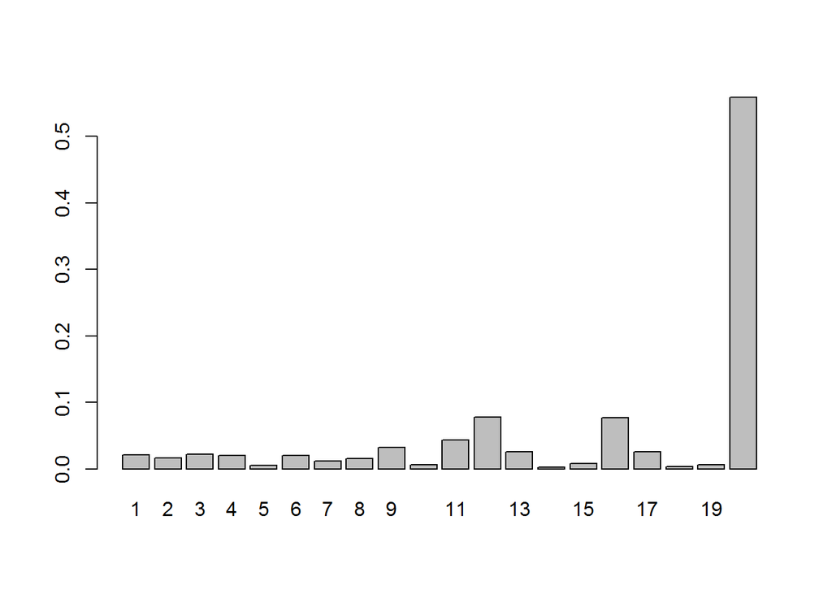

```r
barplot(posterior[d,])
```

```r
# Examine the main topic for document d
Terms[[which.max(posterior[d,])]]
```

```
## [1] "code"   "find"   "page"   "peopl"  "phone"  "search" "zip"
```

```r
# Compare the keyword of document d to the terms.
#keywords$query[d]
```

**Keyword 1: Yellow Pages - Topic returned: Yellow pages - matches**

## Keyword Ambiguity

Now that we have run LDA and are able to see the document distributions across topics, we want to use this to quantify the ambiguity of each keyword. We are going to use entropy to measure the ambiguity of a keyword:

$$\begin{equation*}
Entropy(\text{keyword}_i) = - \sum_{t = 1}^{T}{p_{i,t} log(p_{i,t})}
\end{equation*}$$

where $p_{i,t}$ is the probability that the organic search text capturing the context of keyword $i$, is composed of topic $t$, and $T=20$ in our case of 20 topics. Write a general function to compute entropy, given a vector of probabilities.

```r
entropy <- function(probs)
{
entropy_var=0
  for(i in probs)
  {
   entropy_var=entropy_var+(-i*log2(i))
  }
return(entropy_var)
}
```

use this `entropy` function to generate a graph of entropy over the interval $[0,1]$.

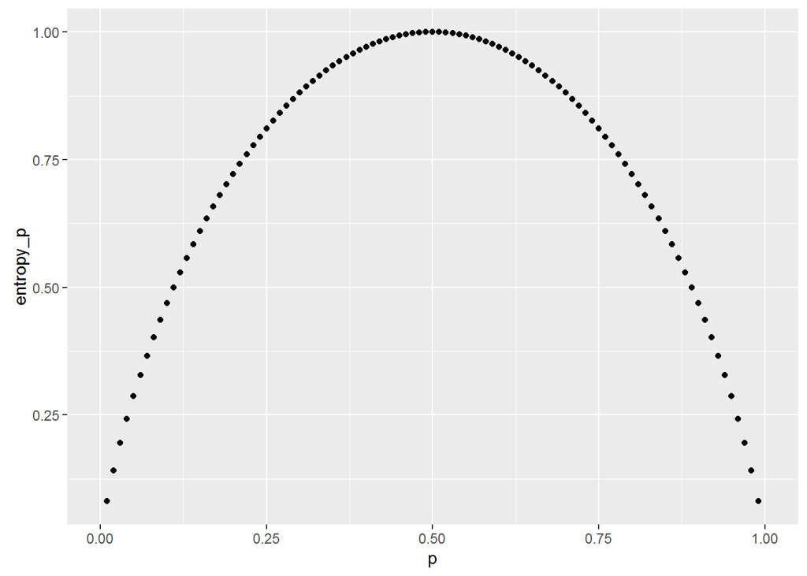

```r
p<-seq(0,1,by=0.01)
entropy_p<-c()

for(i in p)
{
x<-c(i,1-i)
entropy_p<-append(entropy_p, entropy(x), after = length(entropy_p))
}

#plot(p,entropy_p)

ggplot(data=data.frame(p,entropy_p),aes(p,entropy_p)) +geom_point()
```

**Entropy captures the purity of data. As the graph shows, highly impure data with equal probabilities of 2 classes has higher entropy than when there is a dominance of one single class. In other words, highly pure data has low entropy**.

Create a new column in the keyword data that captures the entropy of each keyword

```r
keyword_entropy<-apply(posterior,1,entropy)

querycode<-str_extract(rownames(posterior), "[0-9]+")

entropy_df<-data.frame(querycode,keyword_entropy)
rownames(entropy_df)<-NULL

keywords<-merge(keywords,entropy_df,by="querycode")
```

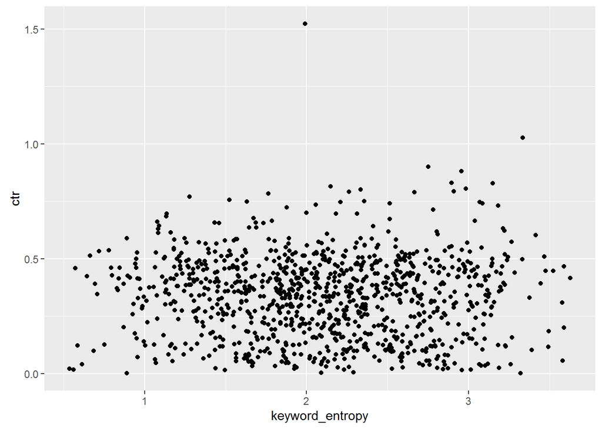

```r
ggplot(keywords, aes(keyword_entropy, ctr)) +geom_point()
```

Re-run the regressions from above, adding this new entropy measure as an additional independent variable

```r
reg<-with(keywords,lm(ctr ~
                      log(num_ads)
                      +log_imp
                      +num_word
                      +brand
                      +location
                      +log_trans
                      +avg_ad_quality
                      +log(avg_num_ads)
                      +categoryid
                      +keyword_entropy
                      ))
summary(reg)
```

```
##
## Call:
## lm(formula = ctr ~ log(num_ads) + log_imp + num_word + brand +
##     location + log_trans + avg_ad_quality + log(avg_num_ads) +
##     categoryid + keyword_entropy)
##
## Residuals:
##      Min       1Q   Median       3Q      Max
## -0.42688 -0.05893 -0.00621  0.05299  0.38954
##
## Coefficients:
##                    Estimate Std. Error t value Pr(>|t|)
## (Intercept)       -0.015960   0.047609  -0.335   0.7375
## log(num_ads)      16.639385   1.006745  16.528   <2e-16 ***
## log_imp          -16.677540   1.006396 -16.572   <2e-16 ***
## num_word          -0.006076   0.004906  -1.238   0.2159
## brand1            -0.008432   0.006488  -1.300   0.1940
## location1         -0.001330   0.010062  -0.132   0.8949
## log_trans          0.007224   0.003365   2.147   0.0321 *
## avg_ad_quality     2.130346   0.101078  21.076   <2e-16 ***
## log(avg_num_ads) -16.410195   1.008209 -16.277   <2e-16 ***
## categoryid1        0.027687   0.025059   1.105   0.2695
## categoryid2        0.009681   0.018792   0.515   0.6065
## categoryid3       -0.035790   0.022329  -1.603   0.1093
## categoryid4        0.017114   0.018269   0.937   0.3491
## categoryid5       -0.028047   0.019730  -1.422   0.1555
## categoryid6        0.031540   0.019465   1.620   0.1055
## categoryid7        0.024573   0.024658   0.997   0.3192
## categoryid8        0.014886   0.018574   0.801   0.4230
## categoryid9       -0.011515   0.018168  -0.634   0.5264
## categoryid10       0.026876   0.018028   1.491   0.1363
## categoryid11       0.014576   0.016839   0.866   0.3869
## categoryid12       0.007489   0.022166   0.338   0.7355
## categoryid13      -0.002062   0.021683  -0.095   0.9243
## categoryid14      -0.020115   0.026104  -0.771   0.4411
## categoryid15       0.044897   0.026475   1.696   0.0902 .
## categoryid16      -0.015546   0.020805  -0.747   0.4551
## categoryid17       0.005733   0.021852   0.262   0.7931
## categoryid18       0.015560   0.021083   0.738   0.4607
## categoryid19       0.019789   0.021726   0.911   0.3626
## keyword_entropy    0.004615   0.005159   0.894   0.3713
## ---
## Signif. codes:  0 '***' 0.001 '**' 0.01 '*' 0.05 '.' 0.1 ' ' 1
##
## Residual standard error: 0.08956 on 971 degrees of freedom
## Multiple R-squared:  0.7541, Adjusted R-squared:  0.747
## F-statistic: 106.4 on 28 and 971 DF,  p-value: < 2.2e-16
```

**The results of the model after adding entropy as a predictor suggest that CTR does not have much of an impact on entropy. Ideally CTR should reduce for words with higher entropy or in other words higher ambiguity.**

## Final Analysis and Recommendations

As above, do an exploration and analysis of the specific keyword “target”. Also, consider using other techniques that you have learned in this course (and other) to gain insights.

```r
summary(keywords)
```

```
##    querycode         query              num_ads         num_clicks
##  Min.   :   1.0   Length:1000        Min.   :   788   Min.   : 106.0
##  1st Qu.: 250.8   Class :character   1st Qu.:  2992   1st Qu.: 141.8
##  Median : 500.5   Mode  :character   Median :  5608   Median : 216.0
##  Mean   : 500.5                      Mean   : 11983   Mean   : 396.8
##  3rd Qu.: 750.2                      3rd Qu.: 11317   3rd Qu.: 391.0
##  Max.   :1000.0                      Max.   :590920   Max.   :6984.0
##
##  num_impressions       num_word     brand   location   log_trans
##  Min.   :   121.0   Min.   :1.000   0:668   0:902    Min.   :0.000
##  1st Qu.:   422.5   1st Qu.:1.000   1:332   1: 98    1st Qu.:1.946
##  Median :   813.5   Median :2.000                    Median :2.708
##  Mean   :  2522.2   Mean   :1.633                    Mean   :2.618
##  3rd Qu.:  1800.2   3rd Qu.:2.000                    3rd Qu.:3.367
##  Max.   :292692.0   Max.   :4.000                    Max.   :5.278
##
##  avg_ad_quality        log_imp        avg_num_ads      categoryid
##  Min.   :0.003744   Min.   : 4.796   Min.   :1.139   11     :137
##  1st Qu.:0.026073   1st Qu.: 6.046   1st Qu.:6.513   4      : 87
##  Median :0.045467   Median : 6.701   Median :7.499   9      : 81
##  Mean   :0.049416   Mean   : 6.878   Mean   :6.772   8      : 80
##  3rd Qu.:0.060967   3rd Qu.: 7.496   3rd Qu.:7.853   10     : 79
##  Max.   :0.451305   Max.   :12.587   Max.   :7.996   2      : 77
##                                                      (Other):459
##       ctr           keyword_entropy
##  Min.   :0.001052   Min.   :0.5341
##  1st Qu.:0.202516   1st Qu.:1.6410
##  Median :0.346762   Median :2.1105
##  Mean   :0.336103   Mean   :2.1055
##  3rd Qu.:0.456170   3rd Qu.:2.5789
##  Max.   :1.521978   Max.   :3.6286
##
```

```r
keywords[keywords$query=="target",]
```

```
##     querycode  query num_ads num_clicks num_impressions num_word brand
## 824       824 target   21941        128            3369        1     1
##     location log_trans avg_ad_quality  log_imp avg_num_ads categoryid
## 824        0  3.332205     0.00822721 8.122371    6.511724          8
##            ctr keyword_entropy
## 824 0.03799347        2.761039
```

```r
keywords[keywords$query=="wal mart",]
```

```
##     querycode    query num_ads num_clicks num_impressions num_word brand
## 136       136 wal mart   13715        618            3504        2     1
##     location log_trans avg_ad_quality log_imp avg_num_ads categoryid
## 136        1  3.401197     0.04093389 8.16166    3.904966          8
##           ctr keyword_entropy
## 136 0.1763699        2.176371
```

```r
keywords[keywords$query=="walmart",]
```

```
##   querycode   query num_ads num_clicks num_impressions num_word brand
## 6         6 walmart  141624       4284           24851        1     1
##   location log_trans avg_ad_quality  log_imp avg_num_ads categoryid
## 6        0  3.401197     0.02957067 10.12065    5.692286          8
##         ctr keyword_entropy
## 6 0.1723874        2.187996
```

```r
keywords[keywords$query=="k-mart",]
```

```
##     querycode  query num_ads num_clicks num_impressions num_word brand
## 626       626 k-mart    3819        174             505        2     0
##     location log_trans avg_ad_quality  log_imp avg_num_ads categoryid
## 626        0  3.828641     0.05440588 6.224558     7.49505          8
##           ctr keyword_entropy
## 626 0.3445545        1.883993
```

```r
keywords[keywords$query=="kmart",]
```

```
##    querycode query num_ads num_clicks num_impressions num_word brand
## 22        22 kmart   31114       2157            4880        1     1
##    location log_trans avg_ad_quality log_imp avg_num_ads categoryid
## 22        0   3.78419     0.05648731  8.4929    6.338115          8
##          ctr keyword_entropy
## 22 0.4420082         1.91824
```

```r
keywords[keywords$query=="costco",]
```

```
##     querycode  query num_ads num_clicks num_impressions num_word brand
## 382       382 costco   41057        285            6503        1     1
##     location log_trans avg_ad_quality  log_imp avg_num_ads categoryid
## 382        0  3.135494     0.00804144 8.780019    6.311087          8
##            ctr keyword_entropy
## 382 0.04382593        2.694918
```

**If we compare Target with Walmart, Kmart and costco search terms, we observe that Target has the higehst entropy among all these terms and the least CTR. This makes sense as the ambiguity of the search term Target relative to the others results in lower CTR.**

**The recommendation would be for Target to bid on keywords which have high probabilities for topics related to retail and shopping.**